# Aplicação do algoritmo PSF a séries de vazão naturalizada

Jerônimo Acker D’Ornellas

08/04/2021

## Objetivo

O objetivo do testePSF é realizar a aplicação do algoritmo PSF em séries hidrológicas e comparar o desempenho do algoritmo com outros métodos univariados amplamente usados para os dados da bacia hidrográfica do posto ONS de código 74.

## Pré-requisitos

Pacotes necessários:

```r
if(!require(PSF)) remotes::install_github("neerajdhanraj/PSF")

pacotes <- c(
  "here",
  "usethis",
  "data.table",
  "HEobs",
  "PSF",
  "tidyverse",
  "lubridate",
  "fs",
  "checkmate",
  "xts",
  "hydroGOF",
  "decomposedPSF",
  "ForecastTB",
  "ModelMetrics"
)
# Carregar os pacotes
easypackages::libraries(pacotes)
```

Scripts:

```r
source(here('R', 'load-data.R'))
source(here('R', 'utils.R'))
```

### Dados de vazão

Os dados importados de vazão devem ser regularmente espaçados no tempo. Esta adequação das séries diárias, se necessária, pode ser realizada com a função `complete_dates()` do pacote **`{lhmetools}`**. Assim assegura-se que todas estações possuam 1 observação por dia e sem datas faltantes.

```r
qnat_data <- qnat_dly_ons() %>%
  select(date, qnat, code_stn) %>%
  lhmetools::complete_dates(group = "code_stn")
glimpse(qnat_data)
```

```
#> Rows: 2,796,267
#> Columns: 3
#> $ date     <date> 1931-01-02, 1931-01-03, 1931-01-04, 1931-01-05, 1931-01-06, ~
#> $ code_stn <dbl> 1, 1, 1, 1, 1, 1, 1, 1, 1, 1, 1, 1, 1, 1, 1, 1, 1, 1, 1, 1, 1~
#> $ qnat     <dbl> NA, NA, NA, NA, NA, NA, NA, NA, NA, NA, NA, NA, NA, NA, NA, N~
```

Os dados importados precisam filtrados para o posto de interesse: posto 74 da ONS (G. B. Munhoz).

```r
posto <- 74
qnat_posto <- qnat_data %>%
  dplyr::filter(code_stn == posto)
glimpse(qnat_posto)
```

```
#> Rows: 32,141
#> Columns: 3
#> $ date     <date> 1931-01-02, 1931-01-03, 1931-01-04, 1931-01-05, 1931-01-06, ~
#> $ code_stn <dbl> 74, 74, 74, 74, 74, 74, 74, 74, 74, 74, 74, 74, 74, 74, 74, 7~
#> $ qnat     <dbl> NA, NA, NA, NA, NA, NA, NA, NA, NA, NA, NA, NA, NA, NA, NA, N~
```

Observam-se dados faltantes na série do posto 74, então selecionaremos somente os meses com mais pelo menos 28 observações válidas e anos completos.

```r
# Seleciona observações com pelo menos 28 observações válidas no mês
qnat_posto_mly <- qnat_posto %>%
  dplyr::group_by(date = floor_date(date, "month"), code_stn) %>%
  dplyr::summarise(
    qnat_obs = mean_wise(qnat),
    valid = nvalid(qnat),
    N = n(),
    .groups = "drop"
  ) %>%
  dplyr::filter(valid >= 28)

# check
#str(qnat_posto_mly)
# qnat_posto_mly %>%
#   lhmetools::complete_dates(group = "code_stn", time_step = # "month") %>%
#   str()

# Anos completos
anos_comp <- qnat_posto_mly %>%
  group_by(ano = lubridate::year(date)) %>%
  tally() %>%
  filter(n == 12) %>%
  pull(ano)

# Usa apenas as observações dos anos completos
qnat_posto_mly <- qnat_posto_mly %>%
  filter(lubridate::year(date) %in% anos_comp)

# check
#qnat_posto_mly %>%
#  filter(valid != N)

# Seleciona apenas a data e as observações de vazão
qnat_posto_mly <- qnat_posto_mly %>%
  select(date, qnat_obs)

# check
head(qnat_posto_mly)
```

```
#> # A tibble: 6 x 2
#>   date       qnat_obs
#>   <date>        <dbl>
#> 1 1969-01-01     459.
#> 2 1969-02-01     541.
#> 3 1969-03-01     565.
#> 4 1969-04-01    1207.
#> 5 1969-05-01     686.
#> 6 1969-06-01    1334.
```

```r
tail(qnat_posto_mly)
```

```
#> # A tibble: 6 x 2
#>   date       qnat_obs
#>   <date>        <dbl>
#> 1 2018-07-01     238.
#> 2 2018-08-01     175.
#> 3 2018-09-01     475.
#> 4 2018-10-01    1468.
#> 5 2018-11-01     631.
#> 6 2018-12-01     280.
```

```r
nrow(qnat_posto_mly) %% 12
```

```
#> [1] 0
```

```r
nrow(qnat_posto_mly) %/% 12
```

```
#> [1] 50
```

### Aplicação do algoritmo PSF

```r
#PSF:::convert_datatype(data = qnat_posto_mly["qnat_obs"])

# Retirar observações dos dois últimos anos: 2017 e 2018
(leave_out <- tail(anos_comp, n = 2))
```

```
#> [1] 2017 2018
```

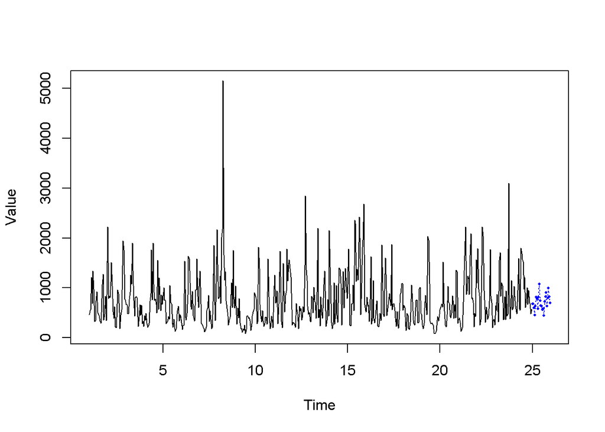

```r
data_train <- qnat_posto_mly %>%
  filter(!lubridate::year(date) %in% leave_out)

# Treinamento do modelo
modelo_munhoz <- psf(
  data_train[["qnat_obs"]],
  #n.ahead = 12 * length(leave_out),
  #k = 2:20,
  k = 3:20,
  w = 1:10,
  cycle = 12
)

# Realiza a previsão de vazão nos dois últimos meses (2017 e 2018)
pred_munhoz <- predict(modelo_munhoz,
                       n.ahead = 12 * length(leave_out))

# Comparação dos valores observados e previstos para os dois últimos anos
plot(
  modelo_munhoz,
  pred_munhoz
  )
```

Adicionando previsões aos dados originais para previsão.

```r
inds <- (nrow(data_train) + 1):(nrow(data_train) + (12 * length(leave_out)))
nrow(qnat_posto_mly) == max(inds)
```

```
#> [1] TRUE
```

```r
qnat_posto_mly_pred <- mutate(qnat_posto_mly,
  qnat_pred = NA,
  qnat_pred = replace(qnat_pred,
    list = inds,
    values = pred_munhoz
  )
)
tail(qnat_posto_mly_pred, 12 * length(leave_out) + 1)
```

```
#> # A tibble: 25 x 3
#>    date       qnat_obs qnat_pred
#>    <date>        <dbl>     <dbl>
#>  1 2016-12-01     570.       NA
#>  2 2017-01-01     971.      677.
#>  3 2017-02-01     806.      674.
#>  4 2017-03-01     454.      593.
#>  5 2017-04-01     259.      452.
#>  6 2017-05-01     586.      632.
#>  7 2017-06-01    1195.      811.
#>  8 2017-07-01     224.      781.
#>  9 2017-08-01     318.      581.
#> 10 2017-09-01     156.      815.
#> # ... with 15 more rows
```

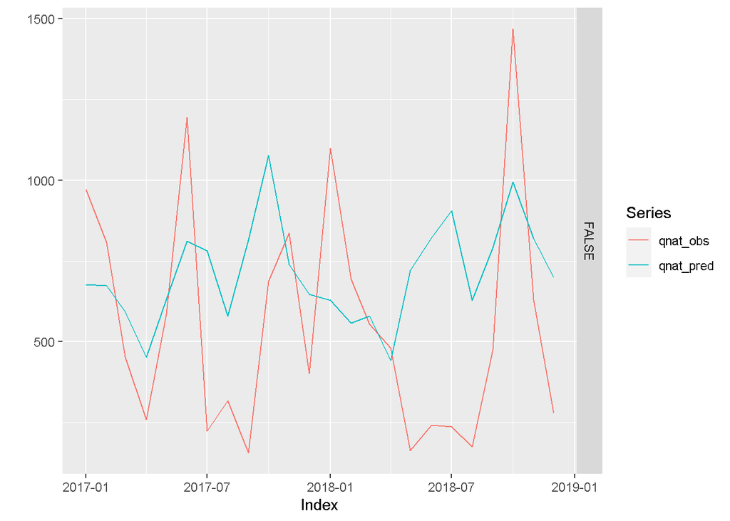

```r
df <- qnat_posto_mly_pred[inds,]
df_ts <- xts(df[,-1], order.by = as.Date(df[["date"]]))
forecast::autoplot(df_ts, facets = FALSE)
```

## Avaliação

```r
# seleciona apenas alguns índices
pos_stat_inds <- c(1:2, 4:6, 9, 17, 19:20)
hydroGOF::gof(
  sim = df_ts$qnat_pred,
  obs = df_ts$qnat_obs)[pos_stat_inds,]
```

```
#>      ME     MAE    RMSE NRMSE % PBIAS %     NSE      R2     KGE      VE
#>  153.10  321.92  377.54  105.80   27.40   -0.17    0.06    0.02    0.42
```

Podemos avaliar a média do RMSE após dez iterações para obter uma resposta mais robusta do desempenho das predições feitas pelo PSF ao alterar, por exemplo, parâmetros como `k` e `w`.

```r
metricas <- NULL

for(i in 1:10)
{
  set.seed(i)
  # PSF
  psf_model <- psf(data_train[["qnat_obs"]],
                   k = 3:20,
                   w = 1:10,
                   cycle = 12)
  preds <- predict(psf_model,
                   n.ahead = 12 * length(leave_out))
  # Erro do PSF
  metricas[i] <-  sqrt(mean((df_ts$qnat_obs- preds)^2))
}


(rmse_psf <- mean(metricas))
```

```
#> [1] 427.24
```

## Aplicação do PSF a outros postos da ONS

O `chunck` abaixo realiza a média mensal dos dados de vazão para cada posto da ONS e seleciona apenas os anos completos, isto é, que apresentam os dados de vazão naturalizada (`qnat`) para todos os meses do ano.

Testando map_df()

```r
# Média mensal das observações de vazão para todos os postos
qnat_mly <- qnat_data %>%
  dplyr::group_by(date = floor_date(date, "month"), code_stn) %>%
  dplyr::summarise(
    qnat_obs = mean_wise(qnat),
    valid = nvalid(qnat),
    N = n(),
    .groups = "drop"
  ) %>%
  dplyr::filter(valid >= 28)



# Análise

#lapply(by_code$data, '[[', 'date') como acessar coluna dentro da lista de df's


# Seleciona apenas data, código do posto e obs de vazão nat.
qnat_mly <- qnat_mly %>%
  select(date,code_stn,qnat_obs)

# Agrupa df pelo código do posto
by_code <- qnat_mly %>%
  group_by(code_stn) %>%
  nest()


# Postos com ano completos (testado ok!)
bycd_cyrs <- by_code %>%
  mutate(data = map(data,apply_cyears))

# Dados de treinamento (sem últimos dois anos)
train_data <- bycd_cyrs  %>%
  mutate(data = map(data, train_data))


# Dados para avaliação do PSF
tst_data <- by_code %>%
  mutate(obs = map(data,test_data)) %>%
  unnest(.,obs) %>%
  select(code_stn,qnat_obs)



# Selecionar qnat_obs --> train_data$data[[i]][:,2] (i = cód posto)

preds_model <- train_data %>%
  mutate(preds = map(data, psf_model))


# Predições e code_stn
preds <- preds_model[-2] %>%
  unnest(.,preds)


# Avaliação do PSf

pos_stat_inds <- c(6, 9, 17, 19)

preds_obs <- preds %>%
  ungroup() %>%
  mutate(qnat_obs = NA,
         qnat_obs = replace(qnat_obs,
                            values = tst_data$qnat_obs)
         ) #%>%
  #$group_by(code_stn)



metricas <- preds_obs %>%
  group_by(code_stn) %>%
  summarise(KGE = KGE(sim = preds, obs = qnat_obs),
            PBIAS = pbias(sim = preds, obs = qnat_obs),
            nse = NSE(sim = preds, obs = qnat_obs),
            RMSE = ModelMetrics::rmse(actual = qnat_obs,
                                      predicted = preds)
            ) %>%
  arrange(-KGE)

(metricas)
```

```
#> # A tibble: 87 x 5
#>    code_stn   KGE PBIAS   nse    RMSE
#>       <dbl> <dbl> <dbl> <dbl>   <dbl>
#>  1      287 0.937   0.8 0.876 4031.
#>  2      145 0.908  -3.2 0.916    9.48
#>  3      281 0.876  -4.7 0.692    6.38
#>  4      278 0.865   5.2 0.778   56.3
#>  5      291 0.863  -6.3 0.815  126.
#>  6       99 0.804  -1.7 0.595    9.61
#>  7      295 0.796  -6.9 0.387    8.12
#>  8      294 0.786   5.3 0.695   30.6
#>  9      246 0.771   7.7 0.660 1415.
#> 10      277 0.763  20.4 0.707   76.8
#> # ... with 77 more rows
```

## Comparação com outros métodos

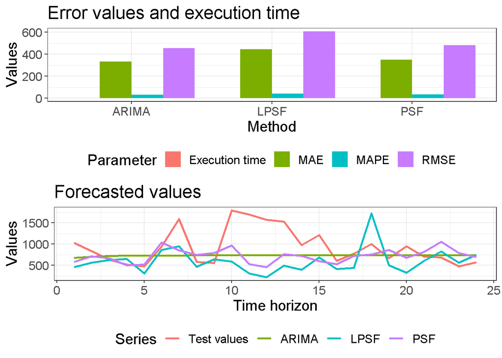

```r
library(tsbox)
# TS
df_comp <- xts(data_train[,2], order.by = as.Date(data_train[["date"]]))
# xts to time series
ts_dfcomp <- ts_ts(df_comp)


# Função para testar o método LPSF
test1 <- function(data, nval){
  return(lpsf(data = data, n.ahead = nval))
}
# Função para testar o método PSF
test2 <- function(data, nval){
  a <- psf(data = data, cycle = 12)
  b <- predict(object = a, n.ahead = nval)
  return(b)
  }

a1 <- prediction_errors(data = ts_dfcomp,
                        nval = 12*length(leave_out),
                        Method = c("test1(data, nval)", "test2(data, nval)"),
                        MethodName = c("LPSF","PSF"),
                        append_ = 1)

b1 <- plot(a1)
```